# Pol Sci 6 Section Notes

## Examining the Distribution of a Variable

Before you examine the distribution of a variable, you need to know whether it is **categorical** or **quantitative** (numerical).

### Distribution of a Categorical Variable

For a categorical variable (such as gender, color, political affiliation), we use `tally()` to get a frequency table, `gf_bar` to get a bar plot, or `gf_percents` to get a percentage plot.

```r
tally(mydata$education) # gives you the frequency of each category.
```

```
## X
##     Bachelors     Doctorate   High School       Masters No HS Diploma
##          5355           413         20241          2299          4253
```

```r
tally(mydata$education, format = "percent") # gives you the percentage of each category.
```

```
## X
##     Bachelors     Doctorate   High School       Masters No HS Diploma
##     16.446055      1.268389     62.163324      7.060594     13.061638
```

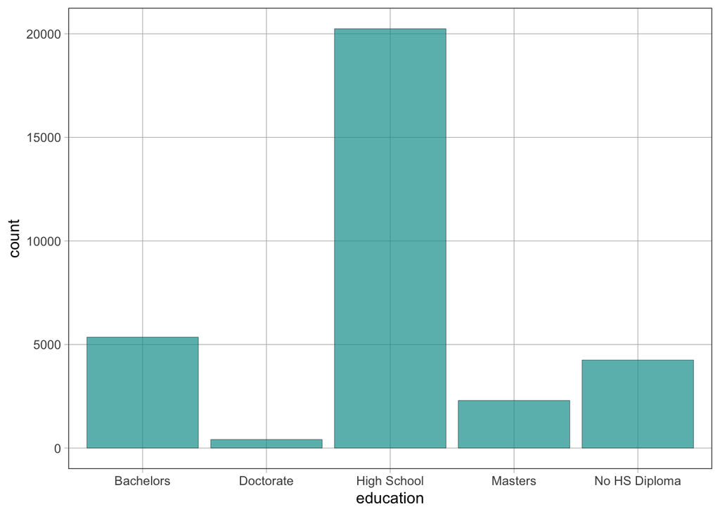

```r
gf_bar(~education, data = mydata) # creates a bar plot: y-axis is the count.
```

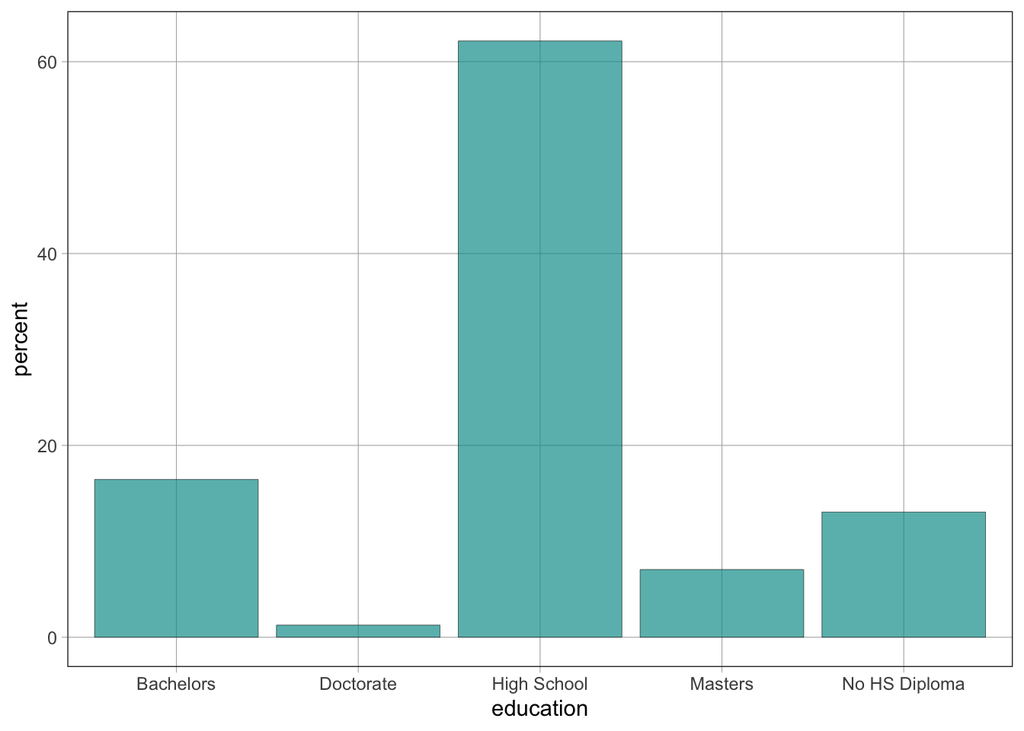

```r
gf_percents(~education, data = mydata) # creates a percent plot: y-axis is the percentage.
```

### Distribution of a Quantitative Variable

For a numerical variable (such as age, GDP, income), we can use `favstats()` to get its summary statistics, or create a density plot, histogram, or boxplot to visualize its distribution.

What are the minimum, maximum, median, mean, IQR, and range of `income`?

```r
favstats(mydata$income)
```

```
##    min    Q1 median    Q3    max     mean       sd     n missing
##  14761 27425  32462 43989 399502 45410.69 32767.73 32561       0
```

Now we can visualize the distribution of `income`.

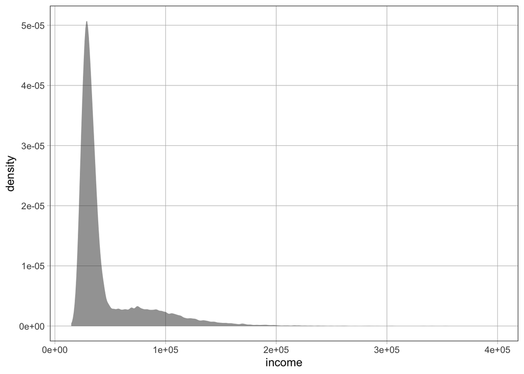

```r
gf_density(~income, data = mydata) # creates a density plot.
```

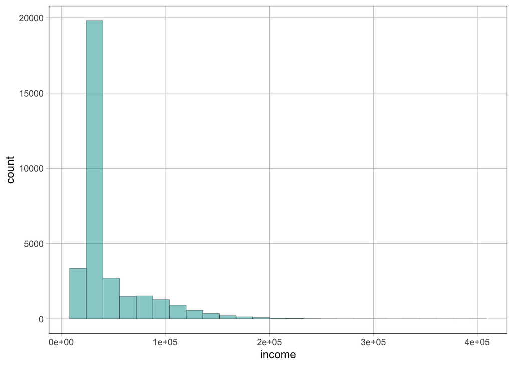

```r
gf_histogram(~income, data = mydata) # creates a histogram.
```

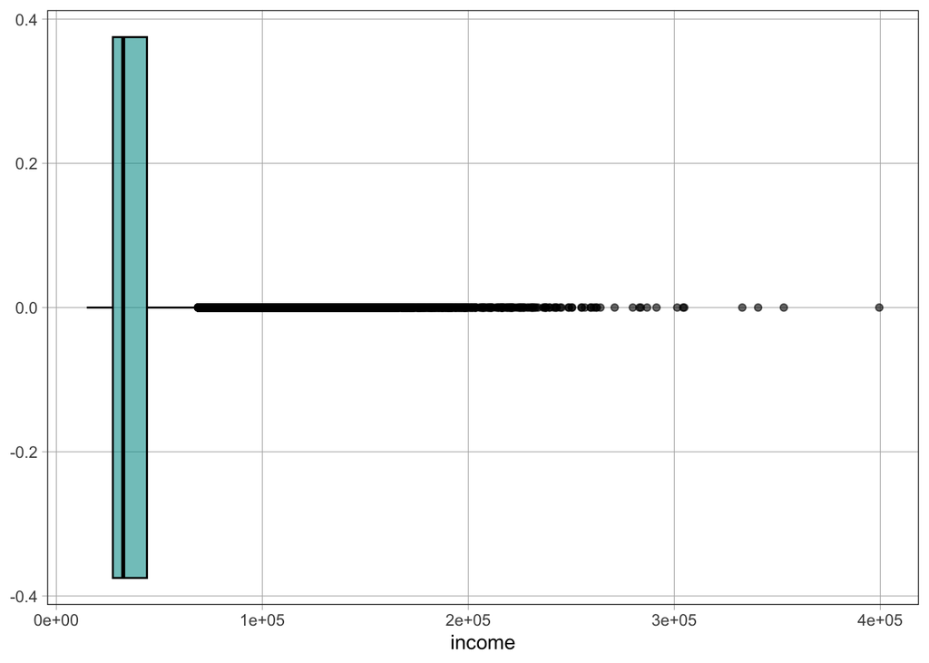

```r
gf_boxplot(~income, data = mydata) # creates a boxplot, which contains more details like median and range.
```

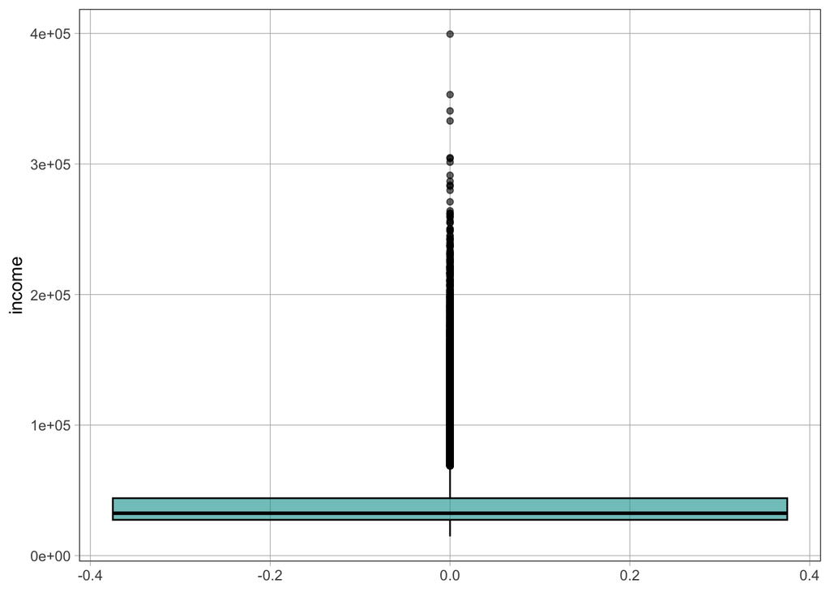

```r
gf_boxplot(income ~ ., data = mydata) # creates a boxplot (vertical). The dot is a placeholder.
```

The distribution is **skewed right**. Lots of people earn less than $50,000, and a small proportion of people earn much more.

## Examining the Distribution of Two Variables

### A Quantitative Variable and A Categorical Variable

If we are interested in the distribution of a numerical variable (`income`) across different categories (`gender`):

```r
favstats(income ~ gender, data = mydata) # gives you the summary statistics of `income` across different `gender`.
```

```
##   gender   min       Q1 median       Q3    max     mean       sd     n missing
## 1 Female 15157 26747.00  30877 36626.00 332992 37383.89 23859.92 10771       0
## 2   Male 14761 27863.25  33594 58985.75 399502 49378.41 35714.31 21790       0
```

Visualizing the distribution of `income` across different `gender`:

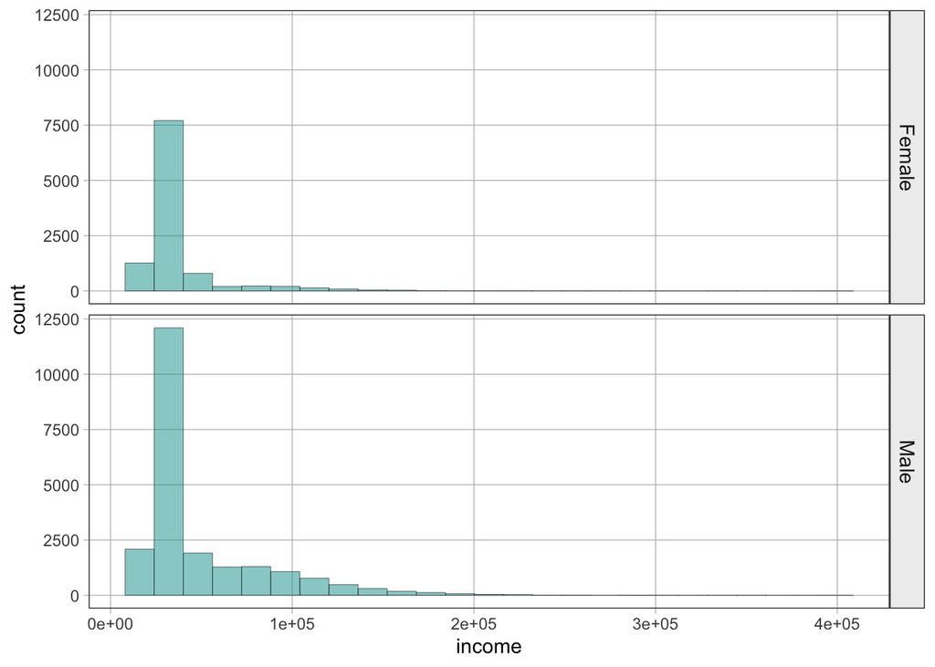

```r
gf_histogram(~income, data = mydata) %>% gf_facet_grid(gender ~ .) # creates a histogram of `income` across different `gender`.
```

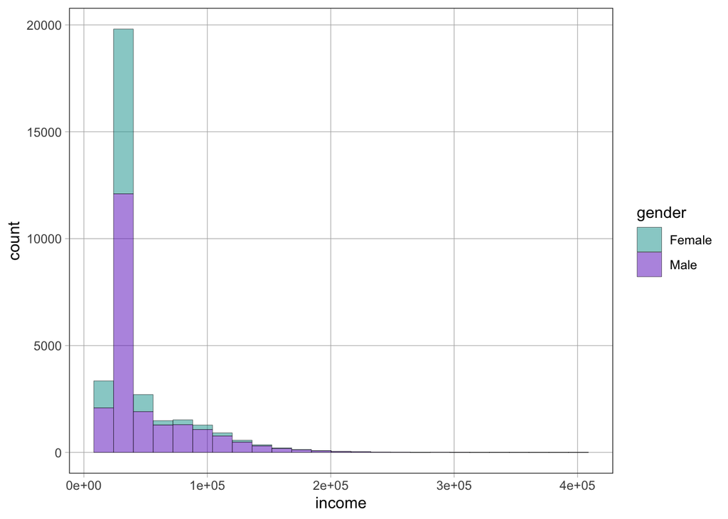

```r
gf_histogram(~income, fill = ~gender, data = mydata) # creates a histogram of `income` across different `gender`, with different colors.
```

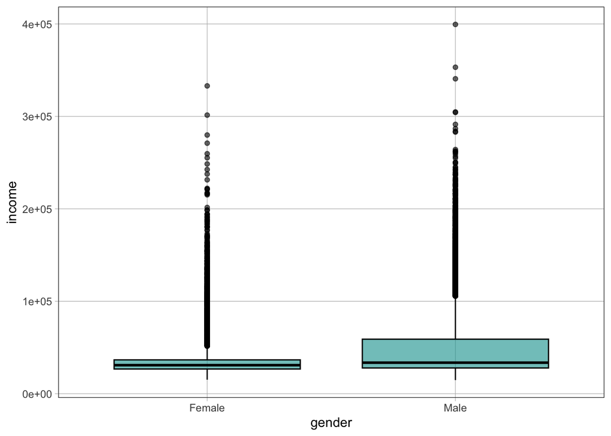

```r
gf_boxplot(income ~ gender, data = mydata) # creates a boxplot of `income` across different `gender`.
```

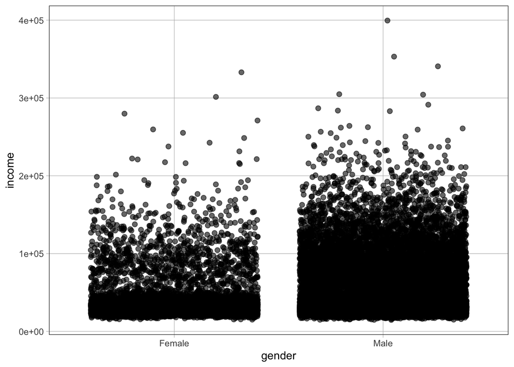

```r
gf_jitter(income ~ gender, data = mydata) # creates a jitter plot of `income` across different `gender`.
```

Note that in this class, we will not cover the case the other way around (a categorical variable across different numerical variables).

### Two Categorical Variables

If we are interested in the distribution of two categorical variables, like `gender` and `education`:

```r
tally(gender ~ education, data = mydata) # gives you the frequency of each combination of `gender` and `education`.
```

```
##         education
## gender   Bachelors Doctorate High School Masters No HS Diploma
##   Female      1619        86        7117     628          1321
##   Male        3736       327       13124    1671          2932
```

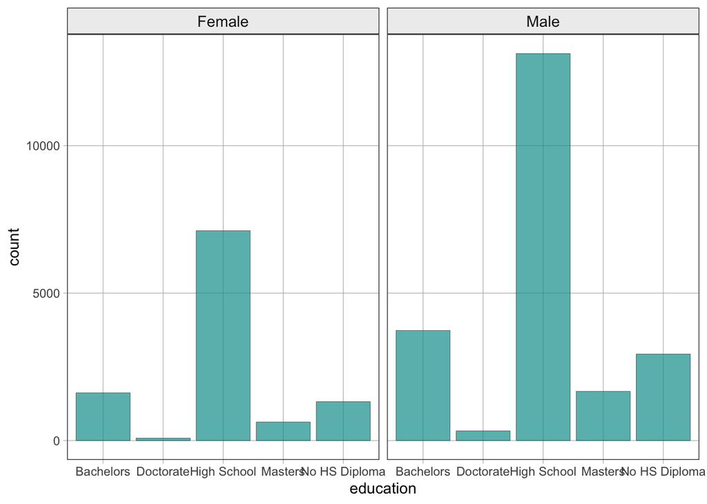

```r
gf_bar(~education, data = mydata) %>% gf_facet_grid(. ~ gender) # creates a bar plot of `education` across different `gender`.
```

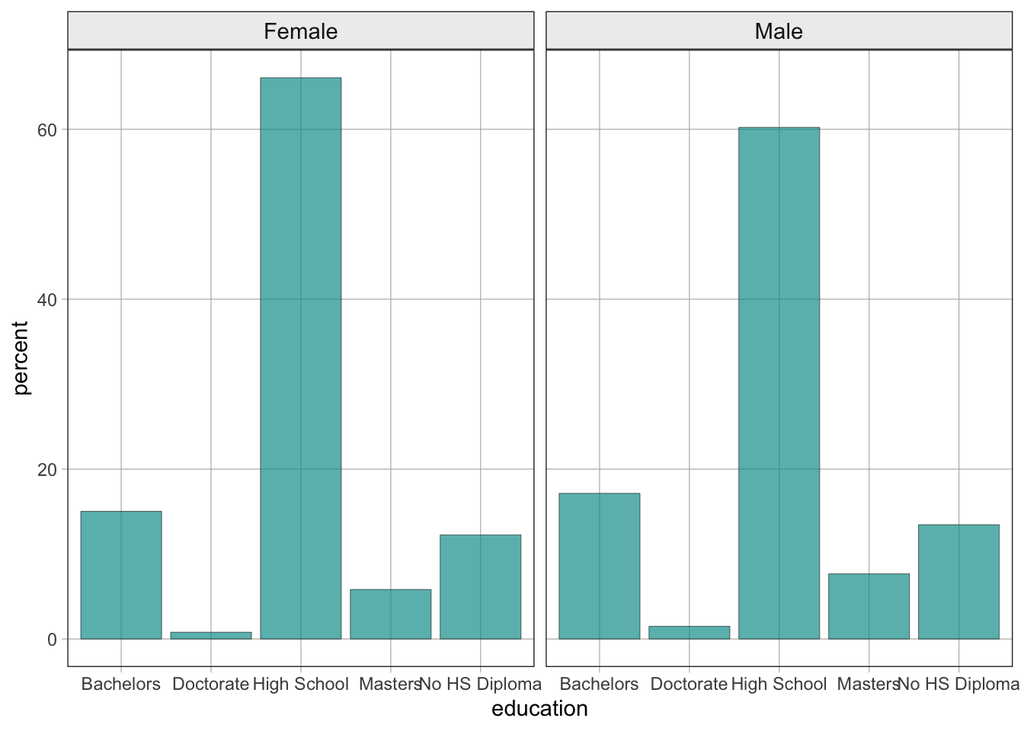

```r
gf_percents(~education, data = mydata) %>% gf_facet_grid(. ~ gender) # creates a percentage plot of `education` across different `gender`.
```

### Two Quantitative Variables

If we are interested in the relationship between two numerical variables, like `income` and `age`:

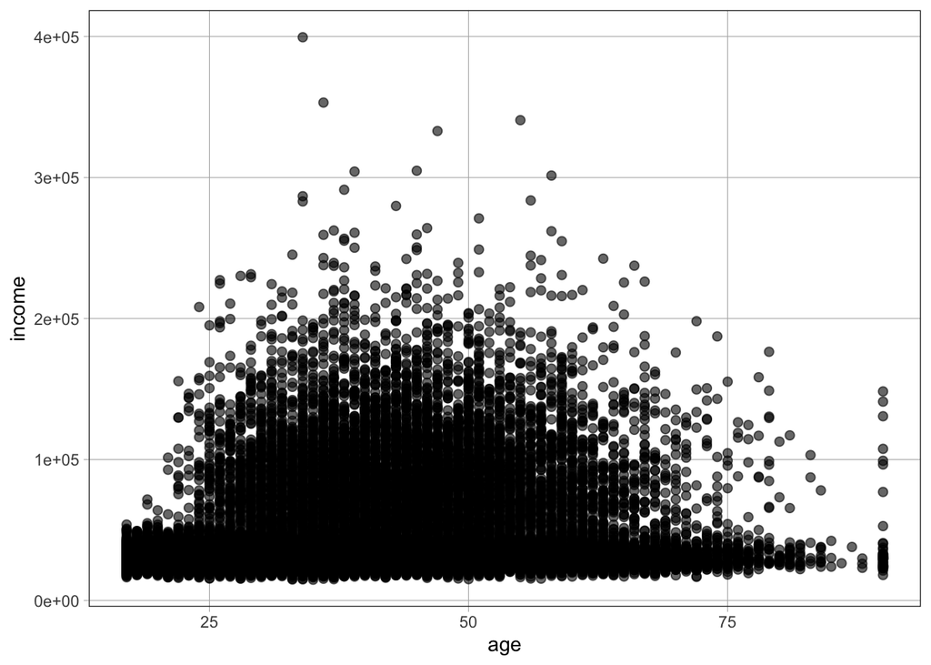

```r
gf_point(income ~ age, data = mydata) # creates a scatter plot of `income` and `age`.
```

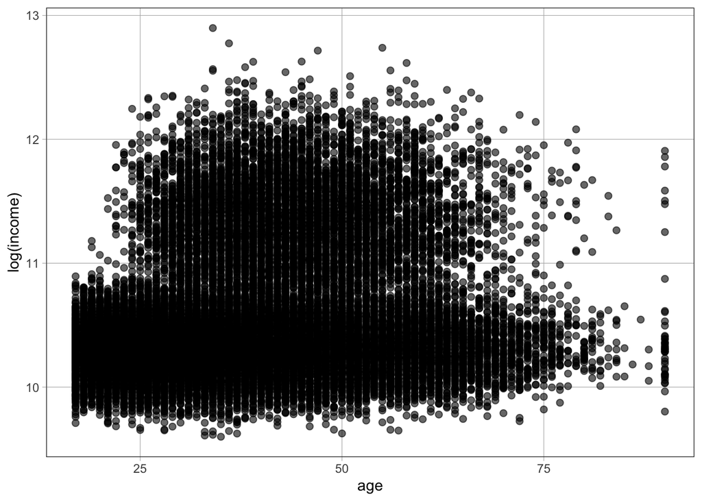

```r
gf_point(log(income) ~ age, data = mydata) # creates a scatter plot of logged `income` and `age`. Note that the y-axis is now in log scale.
```

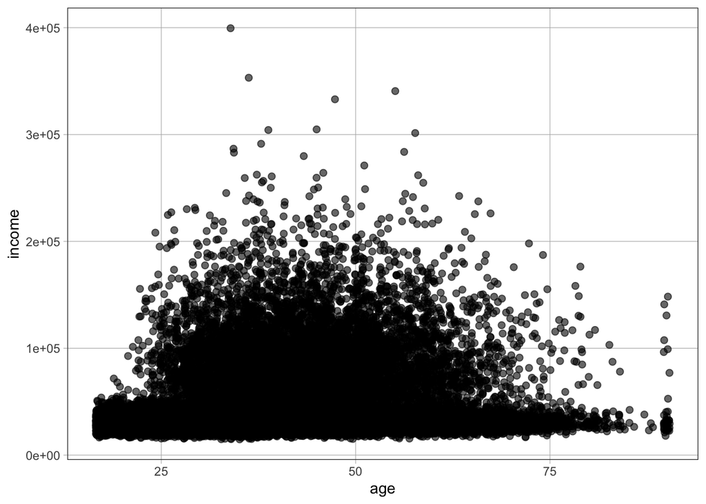

```r
gf_jitter(income ~ age, data = mydata) # creates a jitter plot of `income` and `age`.
```

# Part II - Regression Models

## Empty Model

The simplest model is the empty model, where we use the mean of a quantitative variable to model its distribution. In a word form: `Income = Mean + Error`. In a general linear model form: $\text{Income}_i = b_0 + e_i$.

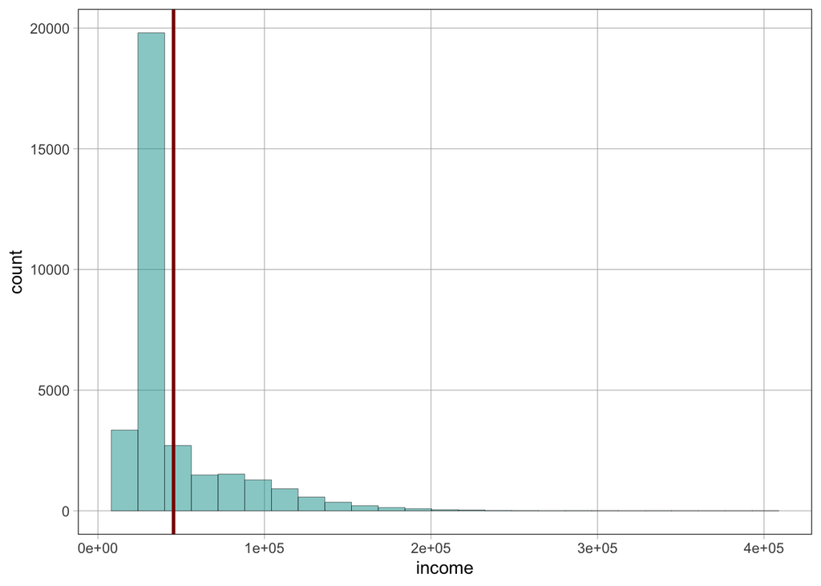

```r
# create a histogram of `income` and add a vertical line at the mean of `income`.
gf_histogram(~income, data = mydata) %>%
  gf_vline(xintercept = ~mean, data = favstats(~income , data = mydata), color ="darkred")
```

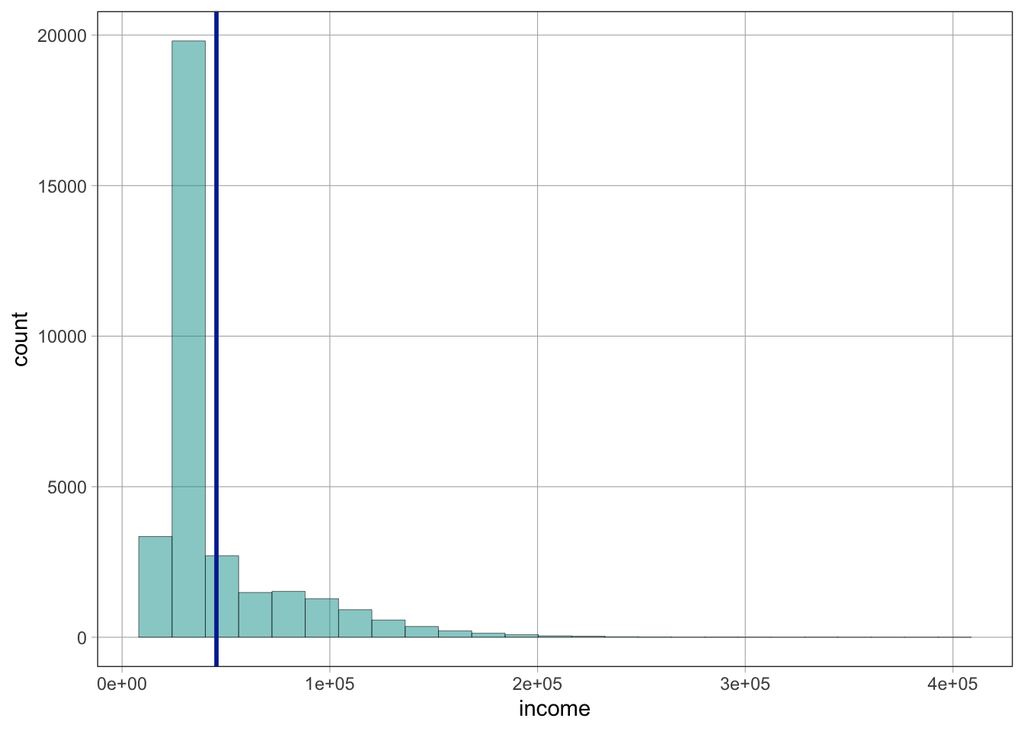

```r
# create an empty model
empty_model <- lm(income ~ NULL, data = mydata)

# Visualize the empty model prediction
gf_histogram(~income, data = mydata) %>% gf_model(empty_model) # the same as the previous plot
```

```r
# get the predictions from the empty model
mydata$empty_predicted <- predict(empty_model)

# check your model, it only has one intercept, which equals the mean of `income`.
empty_model
```

```
##
## Call:
## lm(formula = income ~ NULL, data = mydata)
##
## Coefficients:
## (Intercept)
##       45411
```

```r
mean(mydata$income)
```

```
## [1] 45410.69
```

```r
# data_i = b_0 (mean) + error_i (residual)
# to get the residuals
mydata$empty_residuals <- resid(empty_model)
mean(mydata$empty_residuals) # should be 0
```

```
## [1] -4.086115e-11
```

```r
# calculate the SAD (sum of absolute deviations/residuals/errors)
sum(abs(mydata$empty_residuals))
```

```
## [1] 742842665
```

```r
# calculate the SSE (sum of squared errors)
sum(mydata$empty_residuals^2)
```

```
## [1] 3.496045e+13
```

```r
# calculate the variance (mean squared error; MSE)
var(mydata$income) # var() function
```

```
## [1] 1073723810
```

```r
sum(mydata$empty_residuals^2) / (nrow(mydata)-1) # variance = SSE/(n-1)
```

```
## [1] 1073723810
```

```r
# calculate the SD (standard deviation)
sd(mydata$income) # sd() function
```

```
## [1] 32767.73
```

```r
sqrt(var(mydata$income)) # SD = sqrt(variance), the square root of the variance
```

```
## [1] 32767.73
```

## Simple Linear Model

The simple linear model is a regression model with one predictor. We refer to the X as the **independent (explanatory) variable** and Y as the **dependent (response)** variable.

### Fit the Model

First, let’s explain variation in income using age, a continuous variable. In a word form: `Income = Age + Error`. In a general linear model form: $\text{Income}_i = b_0 + b_1*\text{Age}_i + e_i$ (plug in the estimated `b0` and `b1` we get).

```r
age_model <- lm(income ~ age, data = mydata) # explain income using age
summary(age_model) # get the summary of the model
```

```
##
## Call:
## lm(formula = income ~ age, data = mydata)
##
## Residuals:
##    Min     1Q Median     3Q    Max
## -50676 -17613 -10443   1180 356172
##
## Coefficients:
##             Estimate Std. Error t value Pr(>|t|)
## (Intercept) 27889.79     534.98   52.13   <2e-16 ***
## age           454.13      13.07   34.74   <2e-16 ***
## ---
## Signif. codes:  0 '***' 0.001 '**' 0.01 '*' 0.05 '.' 0.1 ' ' 1
##
## Residual standard error: 32180 on 32559 degrees of freedom
## Multiple R-squared:  0.03574,    Adjusted R-squared:  0.03571
## F-statistic:  1207 on 1 and 32559 DF,  p-value: < 2.2e-16
```

```r
b0(age_model) # get the intercept
```

```
## [1] 27889.79
```

```r
b1(age_model) # get the slope
```

```
## [1] 454.1253
```

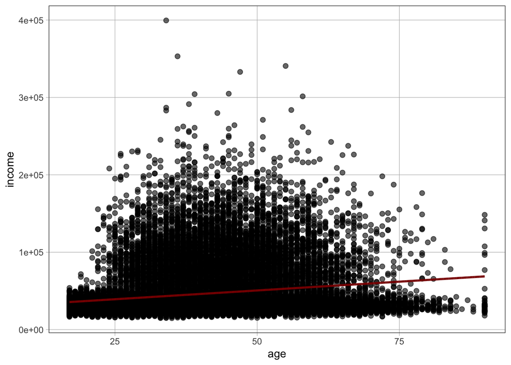

```r
# let's create a scatter plot of `income` and `age`, and add the regression line.
gf_point(income ~ age, data = mydata) %>% gf_model(age_model, color = "darkred")
```

What does the `b0` and `b1` mean here? The `b0` is the intercept, which is the predicted value of `income` when `age` is 0 (hypothetically speaking). The `b1` is the slope, which is the change in `income` per a one-unit change in `age`. Here it means, for each additional year of age, income increases by $454.1252595.

Second, let’s explain variation in income using gender, a categorical variable. In a word form: `Income = Gender + Error`. In a general linear model form: $\text{Income}_i = b_0 + b_1*\text{Gender}_i + e_i$.

```r
gender_model <- lm(income ~ gender, data = mydata) # explain income using gender
summary(gender_model) # get the summary of the model
```

```
##
## Call:
## lm(formula = income ~ gender, data = mydata)
##
## Residuals:
##    Min     1Q Median     3Q    Max
## -34617 -19007 -10845   1491 350124
##
## Coefficients:
##             Estimate Std. Error t value Pr(>|t|)
## (Intercept)  37383.9      311.0  120.20   <2e-16 ***
## genderMale   11994.5      380.2   31.55   <2e-16 ***
## ---
## Signif. codes:  0 '***' 0.001 '**' 0.01 '*' 0.05 '.' 0.1 ' ' 1
##
## Residual standard error: 32280 on 32559 degrees of freedom
## Multiple R-squared:  0.02966,    Adjusted R-squared:  0.02963
## F-statistic: 995.3 on 1 and 32559 DF,  p-value: < 2.2e-16
```

```r
# For a categorical variable, we have a reference level. Here, the reference level is Female. We can tell it from the summary output -- the slope is called `genderMale`.
b0(gender_model) # get the intercept
```

```
## [1] 37383.89
```

```r
b1(gender_model) # get the slope
```

```
## [1] 11994.52
```

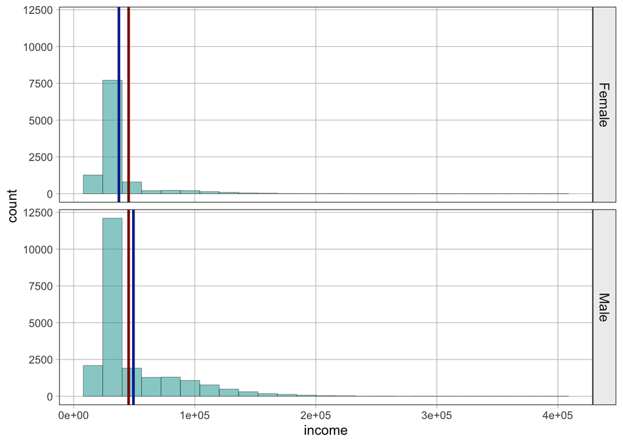

```r
# let's create a histogram of `income` and `gender`, and add the regression line.
gf_histogram(~income, data = mydata) %>% gf_facet_grid(gender ~ .) %>%
  gf_model(gender_model) %>% # gender model: mean income for female and male, separately.
  gf_model(empty_model, color = "darkred") # empty model: mean income for all.
```

What does the `b0` and `b1` mean here? The `b0` is the intercept, which is the mean `income` for the reference level (here it is Female). The `b1` is the slope, which is the difference in `income` between the reference level and the other level (here it is Male). Here it means, the average income of Male is $1.1994522^{4} higher than female.

### ANOVA Table

We have “Total = Model + Error” in the ANOVA table. The `Model` is the variation in `income` explained by the model, and the `Error` is the variation in `income` not explained by the model.

```r
supernova(age_model) # ANOVA table for the age model
```

```
##  Analysis of Variance Table (Type III SS)
##  Model: income ~ age
##
##                                    SS    df           MS        F   PRE     p
##  ----- --------------- | ------------ ----- ------------ -------- ----- -----
##  Model (error reduced) | 1.249373e+12     1 1.249373e+12 1206.675 .0357 .0000
##  Error (from model)    | 3.371107e+13 32559 1.035384e+09
##  ----- --------------- | ------------ ----- ------------ -------- ----- -----
##  Total (empty model)   | 3.496045e+13 32560 1.073724e+09
```

- The 1st column, `SS`, refers to the **sum of squares**. For example, Sum of Squared Errors (SSE) is the `SS` value in the `Error` row, which is 3.3711075^{13}.
- The 2nd column, `df`, refers to the **degrees of freedom**, which depends on the number of observations and variables.
- The 3rd column, `MS`, refers to the **mean square**. `MS` is calculated by dividing `SS` by `df`: for example, `MSE = SSE/df_Error`.